# Creating images with R

with a little bit of magic

Yixuan Liu

```css
body {
    font-family: 'Roboto', sans-serif; /* Changed font family */
    color: #555; /* Darkened text color */
    background-color: #D6EAF8 ; /* Lightened background color */
    line-height: 1.6; /* Increased line height for better readability */
}

h1 {
    color: #2E86C1; /* Changed h1 color to coral */
    font-size: 28px; /* Increased h1 font size */
    margin-bottom: 20px; /* Added margin bottom to h1 for better spacing */
}

p {
    font-size: 18px; /* Increased paragraph font size */
    line-height: 1.4; /* Adjusted line height for paragraphs */
    margin-bottom: 15px; /* Added margin bottom to paragraphs for better spacing */
}
```

## Project requirements

GitHub: I have created a GitHub repository named “stats220” to store all project files. The repository includes folders for different components of the project. There is a README.md which shows a part of me with my brief introduction. There is the Github link to see my introduction. https://sherryixuan.github.io/stats220/

This link shows my work in project1 which use basic R to create a image by combining the picture or blank, and the second part is creating a gif with the image.

The screenshot of files and images created with .Rproject is here:

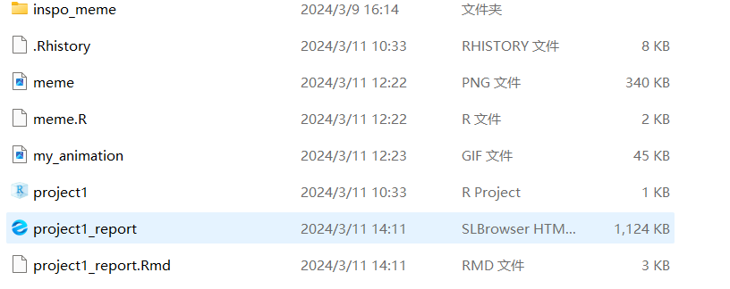

```r
screenshot <- image_read("C:/Users/14580/Desktop/1710122978184.png")
screenshot
```

## My meme

[figure not shown]

```r
meme1 <- image_read(path='https://img.freepik.com/free-vector/simple-vibing-cat-square-meme_742173-4493.jpg?w=740&t=st=1709951033~exp=1709951633~hmac=26fa1d8a8aa151ea49277bb066c5583f070e8605631d82a08fe43198f0d02bdc')
meme1_scale <- image_scale(meme1,180) # change the size of image

meme2 <- image_read("https://encrypted-tbn0.gstatic.com/images?q=tbn:ANd9GcRWjvvbcDgRtZiqBD6YT_J9Jic0LXmv-fDiSrM-P9GEfgxAHvKEH-wnd9s2cA&s")
meme2_scale <- image_scale(meme2,180) # change the size of image


blank1 <- image_blank(width = 180,height=180,color="#F0F0F0") %>%
  image_annotate(text = "calm down",
                 color = "#555",
                 size = 36,
                 font = "center")


blank2 <- image_blank(width = 180,height=180,color="#F0F0F0") %>%
  image_annotate(text = "Failed",
                 color = "#555",
                 size = 40,
                 font = "center")

combin <- c(blank1,meme1_scale,meme2_scale,blank2)# make 3 image into 1 picture
combin_scale <- image_scale(combin,180)
final_image <- image_append(combin_scale)
final_image
```

[figure not shown]

```r
animation <- combin_scale %>%
  image_animate(fps = 1)

image_write(animation, "my_animation.gif")
```

## Creativity

I used image_scale() to change the size of image that I read via website. And on GitHub, I used a star character and a picture of my dog photoed by me, and also I linked my major and my favorite movie character.

## Learning reflection

Important Ideal: In module 1, I learned how to create a html_document in R studio, and some markdown language that I never know before. Before taking Stats 220, I know R in stats201, but I never know that how these code be written. After learning Stats 220, I can input the image from website and annotate it with my ideal. And one more important skill is changing the background color and the word style in output html_document which is the most exciting things that I think. I am more curious in Graph Databases and Analytics, With the rise of interconnected data in social networks, recommendation systems, and knowledge graphs, exploring graph databases and analytical techniques (graph algorithms and graph neural networks) can provide valuable insights into analyzing complex relationships and structures in data.